# Prediction Assignment Writeup

Charmeine Ko

6/29/2020

This project aims to analyze data from accelerometers on the belt, forearm, arm, and dumbell of 6 participants. They were asked to perform barbell lifts correctly and incorrectly in 5 different ways. The resulted data is used to quantify how well they performed the tasks.  
More detailed information is available [here](http://web.archive.org/web/20161224072740/http:/groupware.les.inf.puc-rio.br/har)

### Load Libraries and Download Data

```r
set.seed(42)
# Load library
require(caret)
require(rattle)
# Load data
link_train <- "https://d396qusza40orc.cloudfront.net/predmachlearn/pml-training.csv"
dat <- read.csv(link_train, na.strings=c("","NA"))
link_test <- "https://d396qusza40orc.cloudfront.net/predmachlearn/pml-testing.csv"
pml_test <- read.csv(link_test, na.strings=c("","NA"))
```

### Clean up and Preprocess Data

Several columns contain NA only, so we will remove them prior to analysis. In addition, irrelevant information such as *X*, *user_name*, *raw_timestamp_part_1*, *raw_timestamp_part_2*, *cvtd_timestamp*, *new_window*, *num_window* will also be omitted.

```r
# Remove columns containing NA only and irrelevant information, i.e. column 1-7
clean <- dat[,colSums(is.na(dat))==0]
clean <- clean[,-c(1:7)]

# Split into training and testing sets
train_part <- caret::createDataPartition(clean$classe, p=0.70, list=F)
train <- clean[train_part,]
test <- clean[-train_part,]
```

### Model Fitting

#### 1. Regression Trees

```r
fit_rpart <- train(classe ~ ., data = train, method = "rpart")
pred_rpart <- predict(fit_rpart, test)
confusionMatrix(test$classe, pred_rpart)
```

```
## Confusion Matrix and Statistics
##
##           Reference
## Prediction    A    B    C    D    E
##          A 1520   24  130    0    0
##          B  489  383  267    0    0
##          C  478   31  517    0    0
##          D  429  181  354    0    0
##          E  150  146  293    0  493
##
## Overall Statistics
##
##                Accuracy : 0.495
##                  95% CI : (0.4821, 0.5078)
##     No Information Rate : 0.521
##     P-Value [Acc > NIR] : 1
##
##                   Kappa : 0.3399
##
##  Mcnemar's Test P-Value : NA
##
## Statistics by Class:
##
##                      Class: A Class: B Class: C Class: D Class: E
## Sensitivity            0.4958  0.50065  0.33120       NA  1.00000
## Specificity            0.9454  0.85234  0.88228   0.8362  0.89076
## Pos Pred Value         0.9080  0.33626  0.50390       NA  0.45564
## Neg Pred Value         0.6329  0.91951  0.78514       NA  1.00000
## Prevalence             0.5210  0.12999  0.26525   0.0000  0.08377
## Detection Rate         0.2583  0.06508  0.08785   0.0000  0.08377
## Detection Prevalence   0.2845  0.19354  0.17434   0.1638  0.18386
## Balanced Accuracy      0.7206  0.67650  0.60674       NA  0.94538
```

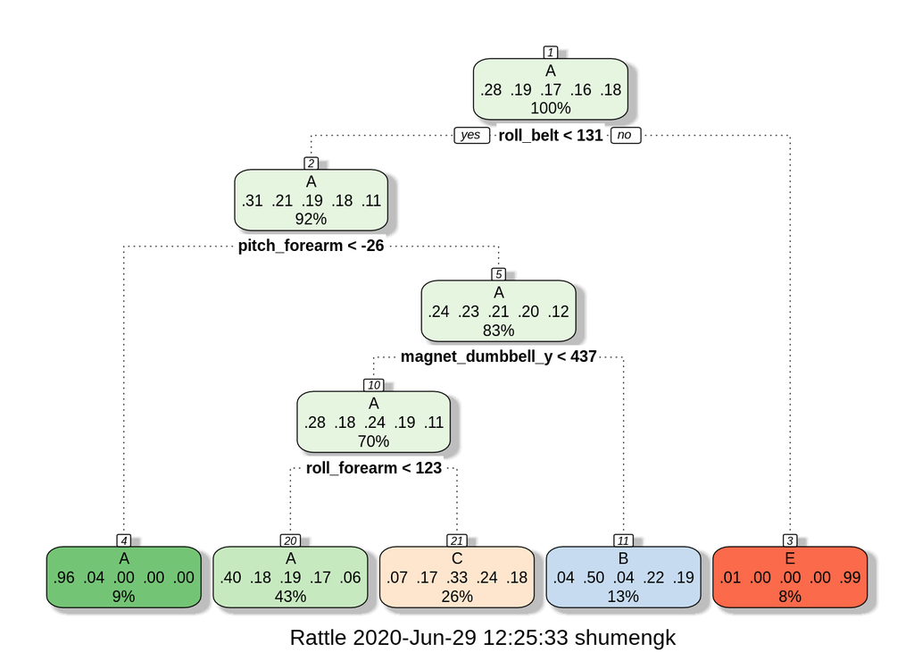

```r
fancyRpartPlot(fit_rpart$finalModel)
```

Regression Trees result in high out-of-sample error, for the accuracy is approximately at 0.5, roughly equivalent to random chance.

#### 2. Linear Discriminant Analysis (LDA)

```r
fit_lda <- train(classe ~ ., data = train, method = "lda")
pred_lda <- predict(fit_lda, test)
confusionMatrix(test$classe, pred_lda)
```

```
## Confusion Matrix and Statistics
##
##           Reference
## Prediction    A    B    C    D    E
##          A 1372   42  151  104    5
##          B  185  718  131   51   54
##          C  104  110  662  128   22
##          D   68   43  102  709   42
##          E   48  180   95  103  656
##
## Overall Statistics
##
##                Accuracy : 0.6996
##                  95% CI : (0.6877, 0.7113)
##     No Information Rate : 0.302
##     P-Value [Acc > NIR] : < 2.2e-16
##
##                   Kappa : 0.6195
##
##  Mcnemar's Test P-Value : < 2.2e-16
##
## Statistics by Class:
##
##                      Class: A Class: B Class: C Class: D Class: E
## Sensitivity            0.7721   0.6569   0.5802   0.6475   0.8421
## Specificity            0.9265   0.9121   0.9233   0.9468   0.9166
## Pos Pred Value         0.8196   0.6304   0.6452   0.7355   0.6063
## Neg Pred Value         0.9038   0.9210   0.9014   0.9216   0.9744
## Prevalence             0.3020   0.1857   0.1939   0.1861   0.1324
## Detection Rate         0.2331   0.1220   0.1125   0.1205   0.1115
## Detection Prevalence   0.2845   0.1935   0.1743   0.1638   0.1839
## Balanced Accuracy      0.8493   0.7845   0.7517   0.7971   0.8793
```

The out-of-sample error of LDA is lower than Regression Tree, achieving an accuracy of around 0.7.

#### 3. Random Forest

```r
fit_rf <- train(classe ~ ., data = train, prox = TRUE, method = "rf", ntrees = 100)
pred_rf <- predict(fit_rf, test)
confusionMatrix(test$classe, pred_rf)
```

```
## Confusion Matrix and Statistics
##
##           Reference
## Prediction    A    B    C    D    E
##          A 1672    1    1    0    0
##          B    1 1135    3    0    0
##          C    0    4 1021    1    0
##          D    0    0   10  953    1
##          E    0    0    0    5 1077
##
## Overall Statistics
##
##                Accuracy : 0.9954
##                  95% CI : (0.9933, 0.997)
##     No Information Rate : 0.2843
##     P-Value [Acc > NIR] : < 2.2e-16
##
##                   Kappa : 0.9942
##
##  Mcnemar's Test P-Value : NA
##
## Statistics by Class:
##
##                      Class: A Class: B Class: C Class: D Class: E
## Sensitivity            0.9994   0.9956   0.9865   0.9937   0.9991
## Specificity            0.9995   0.9992   0.9990   0.9978   0.9990
## Pos Pred Value         0.9988   0.9965   0.9951   0.9886   0.9954
## Neg Pred Value         0.9998   0.9989   0.9971   0.9988   0.9998
## Prevalence             0.2843   0.1937   0.1759   0.1630   0.1832
## Detection Rate         0.2841   0.1929   0.1735   0.1619   0.1830
## Detection Prevalence   0.2845   0.1935   0.1743   0.1638   0.1839
## Balanced Accuracy      0.9995   0.9974   0.9927   0.9958   0.9990
```

Random forest results in the highest accuracy and thus the lowest out-of-sample error among all the models tested, so it will be used for the prediction task.

### Prediction

```r
predict(fit_rf, pml_test)
```

```
##  [1] B A B A A E D B A A B C B A E E A B B B
## Levels: A B C D E
```